# Peer-graded Assignment: Statistical Inference Course Project PART 2

## **Resolution Part 2**

Now in the second portion of the project, we're going to analyze the ToothGrowth data in the R datasets package.

*1.* We load the ToothGrowth data in the R datasets package and perform some basic exploratory data analyses

```r
library(datasets)
data(ToothGrowth)
head(ToothGrowth)
```

|  | len | supp | dose |
| --- | --- | --- | --- |
| 1 | 4.2 | VC | 0.5 |
| 2 | 11.5 | VC | 0.5 |
| 3 | 7.3 | VC | 0.5 |
| 4 | 5.8 | VC | 0.5 |
| 5 | 6.4 | VC | 0.5 |
| 6 | 10.0 | VC | 0.5 |

### **EDA**

Data: *The Effect of Vitamin C on Tooth Growth in Guinea Pigs*

Description:

The response is the length of odontoblasts (cells responsible for tooth growth) in 60 guinea pigs. Each animal received one of three dose levels of vitamin C (0.5, 1, and 2 mg/day) by one of two delivery methods, orange juice or ascorbic acid (a form of vitamin C and coded as VC).

*Format*

A data frame with 60 observations on 3 variables.

| [,1] | len | numeric | Tooth length |
| --- | --- | --- | --- |
| [,2] | supp | factor | Supplement type (VC or OJ) |
| [,3] | dose | numeric | Dose in milligrams/day |

We can visualize the dataset easily with a boxplot and coplot:

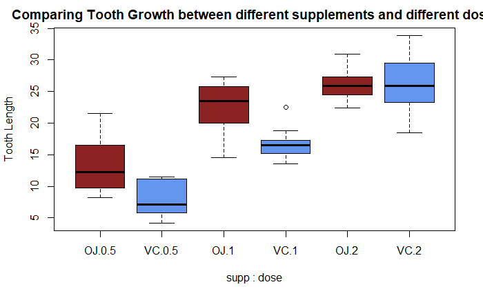

```r
boxplot(len ~ supp * dose, data=ToothGrowth, ylab="Tooth Length", main="Comparing Tooth Growth between different supplements and different dosis", col=c("brown4", "cornflowerblue", "brown4", "cornflowerblue", "brown4", "cornflowerblue"))
```

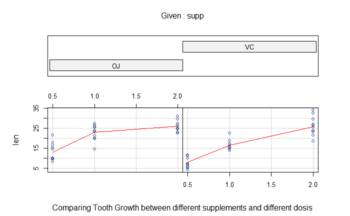

```r
require(graphics)
coplot(len ~ dose | supp, data = ToothGrowth, panel = panel.smooth,xlab = "Comparing Tooth Growth between different supplements and different dosis", col=c("royalblue4"), pch=21)
```

*2.* Provide a basic summary of the data.

As we can see in the plots, the average of the tooth length seems to increase with the supplement dosis. this can mean that it might be a relationship between applying a supplement dosis and the tooth growth.

Further data summaries:

```r
# basic info
head(ToothGrowth)
```

|  | len | supp | dose |
| --- | --- | --- | --- |
| 1 | 4.2 | VC | 0.5 |
| 2 | 11.5 | VC | 0.5 |
| 3 | 7.3 | VC | 0.5 |
| 4 | 5.8 | VC | 0.5 |
| 5 | 6.4 | VC | 0.5 |
| 6 | 10.0 | VC | 0.5 |

```r
nrow(ToothGrowth)
```

```
[1] 60
```

```r
summary(ToothGrowth)
```

```
      len        supp         dose
 Min.   : 4.20   OJ:30   Min.   :0.500
 1st Qu.:13.07   VC:30   1st Qu.:0.500
 Median :19.25           Median :1.000
 Mean   :18.81           Mean   :1.167
 3rd Qu.:25.27           3rd Qu.:2.000
 Max.   :33.90           Max.   :2.000
```

```r
table(ToothGrowth$supp,ToothGrowth$dose)
```

```
     0.5  1  2
  OJ  10 10 10
  VC  10 10 10
```

*3.* Use confidence intervals and/or hypothesis tests to compare tooth growth by supp and dose. (Only use the techniques from class, even if there's other approaches worth considering)

Sample size is not too big, we suggest T distribution

```r
t.test(len ~ supp, data = ToothGrowth)
```

```
    Welch Two Sample t-test

data:  len by supp
t = 1.9153, df = 55.309, p-value = 0.06063
alternative hypothesis: true difference in means is not equal to 0
95 percent confidence interval:
 -0.1710156  7.5710156
sample estimates:
mean in group OJ mean in group VC
        20.66333         16.96333
```

Comparing the difference between the two supplements shows no strong evidence to reject the null hypothesis, since the p-value is bigger than the 5% significance level.

However, for this dataset it is important to also compare the differences between the the different dosis level, since bigger dosis may yield contradicting evidence.

```r
t.test(ToothGrowth$len, ToothGrowth$dose)
```

```
    Welch Two Sample t-test

data:  ToothGrowth$len and ToothGrowth$dose
t = 17.81, df = 59.798, p-value < 2.2e-16
alternative hypothesis: true difference in means is not equal to 0
95 percent confidence interval:
 15.66453 19.62881
sample estimates:
mean of x mean of y
18.813333  1.166667
```

**4.** State your conclusions and the assumptions needed for your conclusions.

As already stated, there is no convincing evidence that there is a difference between the two type of supplements based on the existing datasets and T statistics. meaning **we fail to reject the *Null hypothesis* (H0).**